# Лабораторная работа №7

Операционные системы

Кайнова А. А.

Российский университет дружбы народов, Москва, Россия

23 марта 2024

# Цель работы

Приобрести навыки по работе с файловой системой Linux.

# Задание

1. Выполнить все примеры, приведённые в первой части работы
2. Выполнить некоторые действия, указав в отчёте используемые команды
3. Определить опции команды chmod
4. Проделать приведённые ниже упражнения
5. Прочитать man по командам и кратко их охарактеризовать

# Теоретическое введение

Для создания текстового файла можно использовать команду touch. Для просмотра файлов небольшого размера можно использовать команду cat. Для просмотра файлов постранично удобнее использовать команду less. Команда head выводит по умолчанию первые 10 строк файла. Команда tail выводит умолчанию 10 последних строк файла. Команда cp используется для копирования файлов и каталогов. Команды mv и mvdir предназначены для перемещения и переименования файлов и каталогов.

# Выполнение лабораторной работы

## Выполнить все примеры, приведённые в первой части работы

Скопируем файл ~/abc1 в файл april и в файл may

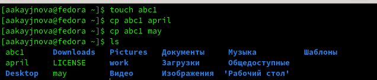

Копирование файла

Скопируем файлы april и may в каталог monthly

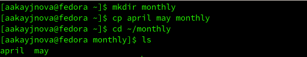

Копирование файла

## Выполнить все примеры, приведённые в первой части работы

Скопируем файл monthly/may в файл с именем june

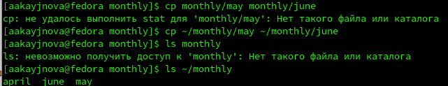

Копирование файла

Скопируем каталог monthly в каталог monthly.00 и каталог monthly.00 в каталог /tmp

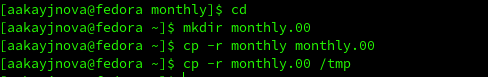

Копирование каталогов

## Выполнить все примеры, приведённые в первой части работы

Изменим название файла april на july

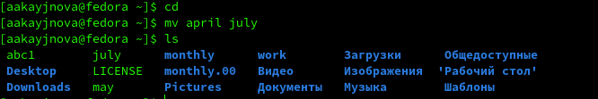

Изменение названия

Переместим файл july в каталог monthly.00

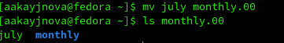

Перемещение файла

## Выполнить все примеры, приведённые в первой части работы

Переименуем каталог monthly.00 в monthly.01

Переместим каталог monthly.01 в каталог reports

## Выполнить все примеры, приведённые в первой части работы

Переименуем каталог monthly.01 в monthly

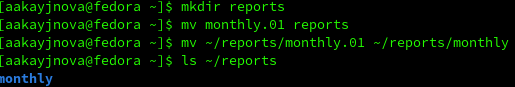

Переименование каталога

Создадим файл ~/may с правом выполнения для владельца

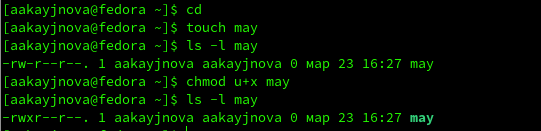

Создание файла

## Выполнить все примеры, приведённые в первой части работы

Лишим владельца прав на выполнение

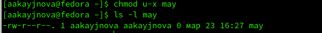

Лишение прав

## Выполнить все примеры, приведённые в первой части работы

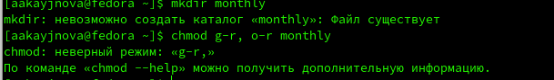

Создание каталога

Создадим файл ~/abc1 с правом записи для членов группы

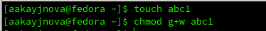

Создание файла

## Выполнить некоторые действия, указав в отчёте используемые команды

Скопируем файл /usr/include/sys/io.h в домашний каталог и назовём его equipment

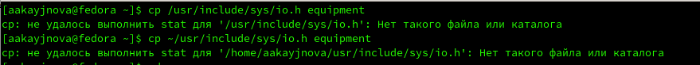

Копирование файла

У меня нет такого файла и каталога, поэтому позже я просто создам файл equipment с расширением h

Создадим директорию ~/ski.plases

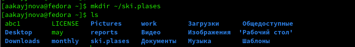

Создание директории

## Выполнить некоторые действия, указав в отчёте используемые команды

Переместим файл equipment в каталог ~/ski.plases

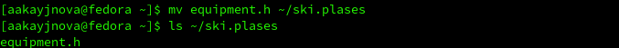

Перемещение файла

Переименуем файл ~/ski.plases/equipment в ~/ski.plases/equiplist

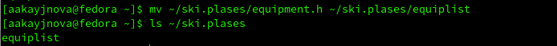

Переименование файла

## Выполнить некоторые действия, указав в отчёте используемые команды

Создадим в домашнем каталоге файл abc1 и скопируем его в каталог ~/ski.plases, назовём его equiplist2

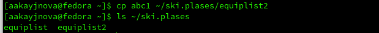

Копирование файла

Создадим каталог с именем equipment в каталоге ~/ski.plases

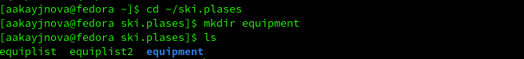

Создание каталога

## Выполнить некоторые действия, указав в отчёте используемые команды

Переместим файла ~/ski.plases/equiplist и equiplist2 в каталог ~/ski.plases/equipment

Создадим и переместим каталог ~/newdir в каталог ~/ski.plases и назовём его plans

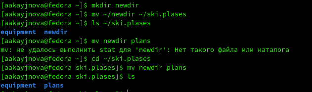

Создание и перемещение каталогов

## Определить опции команды chmod

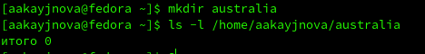

Присвоение прав доступа каталогу

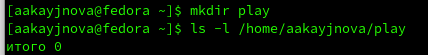

Присвоение прав доступа каталогу

## Определить опции команды chmod

Присвоим права доступа -r-xr–r– файлу my_os

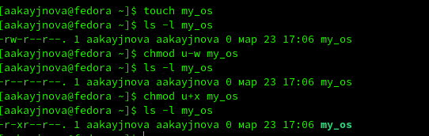

Присвоение прав доступа файлу

Присвоим права доступа -rw-rw-r– файлу feathers

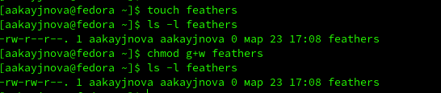

Присвоение прав доступа файлу

## Проделать приведённые ниже упражнения

Просмотрим содержимое файла /etc/password с помощью команды ls

Скопируем файл ~/feathers в файл ~/file.old с помощью команды cp

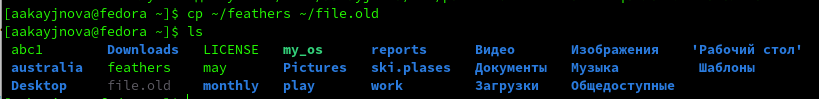

Копирование файла

## Проделать приведённые ниже упражнения

Переместим файл ~/file.old в каталог ~/play с помощью команды mv

Скопируем каталог ~/play в каталог ~/fun с помощью команды cp

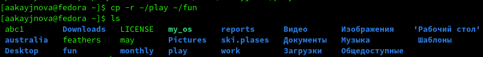

Копирование каталога

## Проделать приведённые ниже упражнения

Переместим каталог ~/fun в каталог ~/play и назовём его games с помощью команды mv

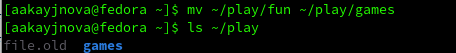

Перемещение каталога

Лишим ладельца файла ~/feathers права на чтение с помощью команды chmod

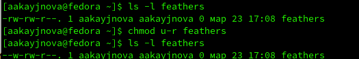

Лишение прав

## Проделать приведённые ниже упражнения

Попытаемся просмотреть файл ~/feathers командой cat

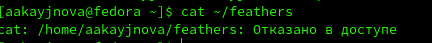

Попытка посмотреть файл

Мы не сможем его просмотреть, т. к. у нас нет прав

## Проделать приведённые ниже упражнения

Попытаемся скопировать файл ~/feathers с помощью команды cp

Мы не можем его скопировать, у нас нет прав

Выдадим владельцу файла ~/feathers право на чтение

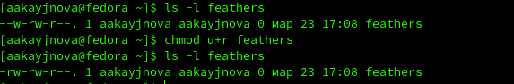

Выдача прав

## Прочитать man по командам и кратко их охарактеризовать

Man по команде mount

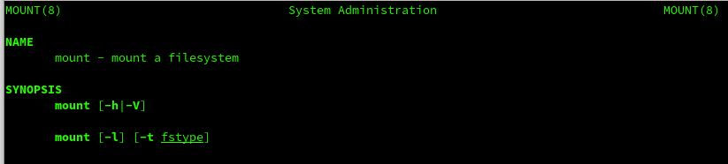

Man mount

Команда mount позволяет пользователям присоединять дополнительную файловую систему к определённой точке монтирования

## Прочитать man по командам и кратко их охарактеризовать

Man по команде fsck

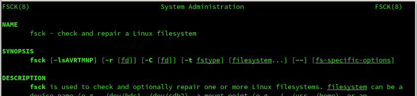

Man fsck

Это утилита для проверки и восстановления файловых систем

## Прочитать man по командам и кратко их охарактеризовать

Man по команде mkfs

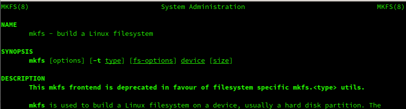

Man mkfs

Команда mkfs используется для создания файловой системы на блочном устройстве, таком как жесткий диск или флэш-накопитель

## Прочитать man по командам и кратко их охарактеризовать

Man по команде kill

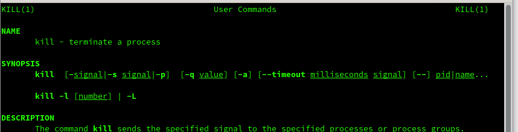

Man kill

Она позволяет прекратить выполнение запущенных процессов

# Выводы

В ходе данной лабораторной работы мы научились работать с файловой структурой Linux

# Список литературы

1. https://esystem.rudn.ru/pluginfile.php/2288087/mod_resource/content/4/005-lab_files.pdf